# act_report

### Act _Report

- So after analyzing our dataset it was observed that the most popular dog stage is pupper which are small doggo and are inexperienced, unfamiliar and unprepared for responsibilities and users got to notice them because they can be playful and messy due to their attributes.
- Then after the pupper, the second most popular dog stage is the doggo which are a big pupper and usually older, not that alone, but they also appear to have their lives in order and are of great use to mankind. in the aspect of helping humans navigate their world i.e They help guide people who have lost their sight, and also they can use their sensitive nose to help humans in locating lost things . One amazing attribute of doggos is their sense of security for human companions because a trained doggo can offer a sense of protection by alerting their owners to approaching strangers or unusual circumstances in the home.
- The relationship between the retweet_count and favorite_count shows there is a positive correlation between them and they are both increasing with respect to each other

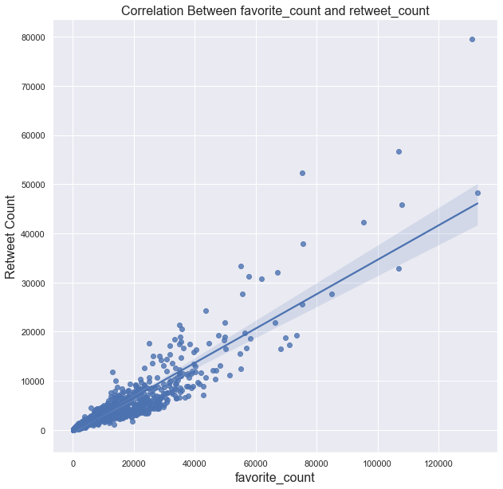

- We also discovered that most of the tweets gotten on our dogs are mainly from Iphone users and we all know the quality Iphones possesses, if we look at the quality of the pictures we have in the dataset, you would notice how clear and of great quality it is.
- It was also clear to us that the dog stage with the most favorite count is the puppo dog which shows that users gave favorite count to them because at their stage they can be trained and get easily understood. Also they are with a mixed bag of both pupper and doggo tendencies.